Universidad Pedagógica y Tecnológica de Colombia

# Taller Práctico II: Análisis Exploratorio de Datos

Especialización en Inteligencia Artificial • Ciencia de Datos y Toma de decisiones

**Estudiante:** José Daniel Rojas Verbel

**Código:** 202624475

**🗂 Repositorio GitHub:** [Repositorio Tarea 2](https://github.com/joserojas07-bit/IA-CienciaDatos2026-2/tree/main/TAREA_2_EDA)

**🌐 Reporte Interactivo:** [Ver Reporte HTML en linea](https://joserojas07-bit.github.io/IA-CienciaDatos2026-2/TAREA_2_EDA/PROTOCOLO/Taller_Practico_II.html)

## 📑 Índice del Taller

- 🎓 Universidad Pedagógica y Tecnológica de Colombia
- Taller práctico II - Preparación de datos para la implementación de modelos de predicción y Optimización del Consumo Energético.
- Objetivo
- Contexto del problema
- 1. Carga y exploración inicial de datos
- 1.1. Cargar los datos
- 1.2. Identificar dimensiones del conjunto de datos
- 1.3. Analizar variables y tipos de datos
- 1.4. Explorar valores unicos por sede
- 1.5. Estadisticas descriptivas del conjunto de datos
- 1.6. Detección de inconsistencias
- 2. Limpieza y preparación inicial
- 2.1. Identificar valores nulos
- 2.2. Seleccion de datos correspondientes a la sede `DUITAMA`
- 2.3. Detección de valores negativos
- 2.4. Limpieza de registros invalidos
- 2.5. Verificación y eliminación de registros duplicados
- 3. Analisis Exploratorio de Datos
- 3.1. Estadistica descriptivas de las variables energetica
- 3.2. Analisis de Histogramas
- 3.3. Imputación de valores nulos
- 3.4. Matriz de correlación
- 4. Preparación para modelado
- 4.1. Selección de variables objetivo y predictoras
- 4.2. Exclusión de variables no relevantes
- 4.3. Conjunto final para entrenamiento

# 🎓 **Universidad Pedagógica y Tecnológica de Colombia**

**📚 Especialización en Inteligencia Artificial · Ciencia de datos y Toma de decisiones**

# Taller práctico II - Preparación de datos para la implementación de modelos de predicción y Optimización del Consumo Energético.

Estudiante: José Daniel Rojas Verbel

Codigo: 202624475

## Objetivo

formar registros de consumo energético en un conjunto de datos limpio, consistente y estructurado, apto para la implementación de modelos de aprendizaje automático orientados a la predicción del consumo energético y al apoyo de estrategias de optimización y sostenibilidad institucional.

## Contexto del problema

La Universidad Pedagógica y Tecnológica de Colombia (UPTC) desarrolla sus actividades académicas y administrativas en cuatro sedes ubicadas en el departamento de Boyacá, con poblaciones estudiantiles y dinámicas operativas diferenciadas:

- Tunja: 18.000 estudiantes
- Duitama: 5.500 estudiantes
- Sogamoso: 6.000 estudiantes
- Chiquinquirá: 2.000 estudiantes

El funcionamiento de estas sedes implica consumos energéticos asociados a distintos sectores institucionales, cada uno con características particulares de uso, demanda y comportamiento temporal:

- Comedores
- Salones
- Laboratorios
- Auditorios
- Oficinas

La heterogeneidad entre sedes y sectores genera variaciones en los patrones de consumo energético, influenciadas por factores como ocupación, horarios académicos, actividades desarrolladas y utilización de infraestructura. Estas condiciones representan una oportunidad para aplicar metodologías de Ciencia de Datos que permitan organizar, depurar y analizar información historica de consumo.

En este contexto, la preparación adecuada de los datos constituye una etapa fundamental para garantizar la calidad de la información que sería utilizada posteriormente en modelos de aprendizaje automático orientados a la predicción del consumo energético, la identificación de patrones de uso ineficiente y el apoyo a estrategias de optimización energética y sostenibilidad institucional.

## 1. Carga y exploración inicial de datos

### 1.1. Cargar los datos

Se llaman las librerias de python ha utilizar durante la ejecución del taller práctico II

```python
# Librerias para trabajo en este documento
import pandas as pd
import numpy as np
import matplotlib.pyplot as plt
import seaborn as sns
```

Se lee el dataset `consumos_uptc.csv` desde google drive hacia el entorno de google Colab.

```python
# Importación de dataset
from google.colab import drive

# Se monta en el punto estándar sin espacios
drive.mount('/content/drive')

# Se accede al archivo especificando la ruta completa dentro de Drive
# Nota: Ajusta 'My Drive' o 'MyDrive' según corresponda en tu estructura de carpetas
ruta_archivo = '/content/drive/My Drive/Colab Notebooks/Especializacion - IA - Ciencia de datos/consumos_uptc.csv'
df_raw = pd.read_csv(ruta_archivo)
```

```
Mounted at /content/drive
```

### 1.2. Identificar dimensiones del conjunto de datos

Se identifican las dimensiones de dataset : `consumos_uptc` que se llamo dentro del entorno de google Colab "df_raw"

```python
print(f'Dimensiones: {df_raw.shape[0]} filas × {df_raw.shape[1]} columnas')
```

```
Dimensiones: 275387 filas × 26 columnas
```

El conjunto de datos inicialmente cuenta con 275387 filas (Instancias) y 26 columnas (Variables).

### 1.3. Analizar variables y tipos de datos

Se hace uso del metodo '.info()' para ver las variables del conjunto de datos y su tipo de datos

```python
# Se obtiene la tabla con la información del conjunto de datos df_raw de las cuatro sedes
df_raw.info()
```

```
<class 'pandas.core.frame.DataFrame'>
RangeIndex: 275387 entries, 0 to 275386
Data columns (total 26 columns):
 #   Column                    Non-Null Count   Dtype
---  ------                    --------------   -----
 0   reading_id                275387 non-null  int64
 1   timestamp                 275387 non-null  object
 2   sede                      275387 non-null  object
 3   sede_id                   275387 non-null  object
 4   energia_total_kwh         275387 non-null  float64
 5   energia_comedor_kwh       267133 non-null  float64
 6   energia_salones_kwh       275387 non-null  float64
 7   energia_laboratorios_kwh  275387 non-null  float64
 8   energia_auditorios_kwh    261769 non-null  float64
 9   energia_oficinas_kwh      275387 non-null  float64
 10  potencia_total_kw         275387 non-null  float64
 11  agua_litros               264405 non-null  float64
 12  temperatura_exterior_c    259002 non-null  float64
 13  ocupacion_pct             242621 non-null  float64
 14  hora                      275387 non-null  int64
 15  dia_semana                275387 non-null  int64
 16  dia_nombre                275387 non-null  object
 17  mes                       275387 non-null  int64
 18  trimestre                 275387 non-null  int64
 19  año                       275387 non-null  int64
 20  periodo_academico         275387 non-null  object
 21  es_fin_semana             275387 non-null  bool
 22  es_festivo                275387 non-null  bool
 23  es_semana_parciales       275387 non-null  bool
 24  es_semana_finales         275387 non-null  bool
 25  co2_kg                    261591 non-null  float64
dtypes: bool(4), float64(11), int64(6), object(5)
memory usage: 47.3+ MB
```

Ahora de observa las columnas con su tipo de dato, y cuatro ejemplos dentro de la columna.

```python
pd.DataFrame({
        'tipo': df_raw.dtypes.astype(str),
        'ejemplos': [df_raw[c].dropna().unique()[:4].tolist() for c in df_raw.columns],
})
```

|  | tipo | ejemplos |
| --- | --- | --- |
| reading_id | int64 | [1, 2, 3, 4] |
| timestamp | object | [2018-01-01 00:00:00, 2018-01-01 01:00:00, 201... |
| sede | object | [Chiquinquirá, Duitama, Sogamoso, Tunja] |
| sede_id | object | [UPTC_CHI, UPTC_DUI, UPTC_SOG, UPTC_TUN] |
| energia_total_kwh | float64 | [0.928, 2.592, 2.841, 1.505] |
| energia_comedor_kwh | float64 | [0.0452, 0.1129, 0.1395, 0.0892] |
| energia_salones_kwh | float64 | [0.1497, 0.2007, 0.2388, 0.1091] |
| energia_laboratorios_kwh | float64 | [0.4334, 1.7993, 1.9638, 0.9672] |
| energia_auditorios_kwh | float64 | [0.0386, 0.0573, 0.0364, 0.0418] |
| energia_oficinas_kwh | float64 | [0.2613, 0.4217, 0.4443, 0.3031] |
| potencia_total_kw | float64 | [1.172, 3.513, 4.336, 1.735] |
| agua_litros | float64 | [25.44, 107.57, 80.13, 1307.49] |
| temperatura_exterior_c | float64 | [6.8, 10.9, 9.2, 5.3] |
| ocupacion_pct | float64 | [4.3, 4.1, 5.7, 4.6] |
| hora | int64 | [0, 1, 2, 3] |
| dia_semana | int64 | [0, 1, 2, 3] |
| dia_nombre | object | [Lunes, Martes, Miércoles, Jueves] |
| mes | int64 | [1, 2, 3, 4] |
| trimestre | int64 | [1, 2, 3, 4] |
| año | int64 | [2018, 2019, 2020, 2021] |
| periodo_academico | object | [vacaciones_fin, semestre1, SEMESTRE_1, Semest... |
| es_fin_semana | bool | [False, True] |
| es_festivo | bool | [True, False] |
| es_semana_parciales | bool | [False, True] |
| es_semana_finales | bool | [False, True] |
| co2_kg | float64 | [0.1877, 0.449, 0.6048, 0.2872] |

### 1.4. Explorar valores unicos por sede

```python
print(f'Sedes unicas: {df_raw['sede'].unique()}')
print(f'\nCantidad de registros por sede: {df_raw['sede'].value_counts()}')
```

```
Sedes unicas: ['Chiquinquirá' 'Duitama' 'Sogamoso' 'Tunja']

Cantidad de registros por sede: sede
Duitama         68862
Chiquinquirá    68859
Tunja           68837
Sogamoso        68829
Name: count, dtype: int64
```

Se identifican que las 4 sedes descritas no tienen nombres de sede que se confundan con mayusculas y minisculas, o que genere duplicados, las 4 sedes estan bien definidas.

- La sede Duitama cuenta con 68862 datos, un 25% del conjunto de datos
- La sede Chiquinquíra cuenta con 68859 datos, un 25% del conjunto de datos
- La sede Tunja cuenta con 68837 datos, un 25% del conjunto de datos
- La sede Sogamoso cuenta con 68829 datos, un 25% del conjunto de datos

### 1.5. Estadisticas descriptivas del conjunto de datos

```python
# Tabla de estadistica descriptiva de las variables numericas
df_raw.describe()
```

|  | reading_id | energia_total_kwh | energia_comedor_kwh | energia_salones_kwh | energia_laboratorios_kwh | energia_auditorios_kwh | energia_oficinas_kwh | potencia_total_kw | agua_litros | temperatura_exterior_c | ocupacion_pct | hora | dia_semana | mes | trimestre | año | co2_kg |
| --- | --- | --- | --- | --- | --- | --- | --- | --- | --- | --- | --- | --- | --- | --- | --- | --- | --- |
| count | 275387.000000 | 275387.000000 | 267133.000000 | 275387.000000 | 275387.000000 | 261769.000000 | 275387.000000 | 275387.000000 | 264405.000000 | 259002.000000 | 242621.000000 | 275387.000000 | 275387.000000 | 275387.000000 | 275387.000000 | 275387.000000 | 261591.000000 |
| mean | 137694.000000 | 5.079227 | 0.295954 | 0.975189 | 2.426430 | 0.097052 | 1.191390 | 6.704269 | 645.323793 | 14.034867 | 22.781399 | 11.499733 | 2.997640 | 6.414936 | 2.476068 | 2021.424461 | 1.015985 |
| std | 79497.523628 | 6.116259 | 0.376617 | 1.620223 | 2.190585 | 0.214350 | 1.407414 | 6.938291 | 1389.793935 | 4.930972 | 20.815521 | 6.922872 | 1.999922 | 3.405917 | 1.107101 | 2.256515 | 1.229521 |
| min | 1.000000 | -38.987575 | 0.004300 | 0.010000 | 0.120600 | 0.003200 | 0.040700 | 0.240000 | 1.950000 | 2.000000 | 1.300000 | 0.000000 | 0.000000 | 1.000000 | 1.000000 | 2018.000000 | -8.509800 |
| 25% | 68847.500000 | 1.464000 | 0.090200 | 0.160100 | 0.798300 | 0.040600 | 0.344900 | 2.004000 | 44.280000 | 10.200000 | 6.300000 | 5.000000 | 1.000000 | 3.000000 | 1.000000 | 2019.000000 | 0.294950 |
| 50% | 137694.000000 | 3.604000 | 0.192300 | 0.316700 | 1.692400 | 0.057400 | 0.662500 | 4.721000 | 138.690000 | 14.000000 | 15.900000 | 12.000000 | 3.000000 | 6.000000 | 2.000000 | 2021.000000 | 0.707800 |
| 75% | 206540.500000 | 5.706000 | 0.391300 | 0.691250 | 3.406205 | 0.084700 | 1.373100 | 8.010500 | 499.760000 | 17.900000 | 31.700000 | 18.000000 | 5.000000 | 9.000000 | 3.000000 | 2023.000000 | 1.174900 |
| max | 275387.000000 | 190.455481 | 3.552500 | 9.534600 | 39.677395 | 2.371300 | 7.821700 | 44.979000 | 62606.262451 | 26.000000 | 90.200000 | 23.000000 | 6.000000 | 12.000000 | 4.000000 | 2025.000000 | 41.119600 |

**Variables temporales.** `hora` (0–23), `dia_semana` (0–6), `mes` (1–12) y `trimestre` (1–4) tienen rangos válidos y no tienen nulos. `año` cubre 2018–2025.

**Valores faltantes.**

| Variable | Faltantes | % |
| --- | --- | --- |
| ocupacion_pct | 32.766 | 11,9 % |
| temperatura_exterior_c | 16.385 | 5,9 % |
| co2_kg | 13.796 | 5,0 % |
| energia_auditorios_kwh | 13.618 | 4,9 % |
| agua_litros | 10.982 | 4,0 % |
| energia_comedor_kwh | 8.254 | 3,0 % |

La ocupación es la más problemática. Como es una variable explicativa clave, imputarla mal puede sesgar los modelos.

**Consumo por zona.**

El consumo de energía muestra según las medias, el reparto aproximado es:

| Zona | Energía media (kWh) | % del total |
| --- | --- | --- |
| Laboratorios | 2,43 | ~48 % |
| Oficinas | 1,19 | ~23 % |
| Salones | 0,98 | ~19 % |
| Comedor | 0,30 | ~6 % |
| Auditorios | 0,10 | ~2 % |

La suma (~4,99) es muy cercana a la media del total (5,08), así que los datos son internamente coherentes en condiciones normales. Los laboratorios son el principal foco de ahorro.

**Anomalías.**

- `energia_total_kwh`: mínimo de −38,99 (imposible físicamente) y máximo de 190,46, frente a un percentil 75 de 5,7 y una suma de máximos por zona de ~63 kWh.
- `co2_kg`: mínimo de −8,51, probablemente heredado de la energía negativa (relación de ~0,2 kg/kWh).
- `agua_litros`: máximo de 62.606 L frente a una mediana de 139 y un percentil 75 de 500. Posible fuga de agua o falla del sensor.
- `energia_laboratorios_kwh` llega a 39,7 (percentil 75: 3,4) y `potencia_total_kw` a 44,98 (percentil 75: 8,0).

**Forma de las distribuciones.**

Hay asimetría positiva fuerte en energía, agua y ocupación, con media mayor que mediana (agua: 645 vs 139; energía total: 5,08 vs 3,60; ocupación: 22,8 vs 15,9). Esto indica poca actividad la mayor parte del tiempo y picos ocasionales. `temperatura_exterior_c` es simétrica (media 14,03; mediana 14,0) y está en un rango plausible (2–26 °C). La ocupación (1,3 %–90,2 %) tiene un rango coherente.

### 1.6. Detección de inconsistencias

```python
pd.DataFrame({
        'tipo': df_raw.dtypes.astype(str),
        'faltantes': df_raw.isna().sum(),
        '% faltantes': (df_raw.isna().mean() * 100).round(1),
        'duplicados': df_raw.duplicated().sum(),
        'nulos': df_raw.isnull().sum(),
        'valores minimos': df_raw.min(numeric_only=True),
        'valores maximos': df_raw.max(numeric_only=True),
        'valores unicos': df_raw.nunique(),
})
```

|  | tipo | faltantes | % faltantes | duplicados | nulos | valores minimos | valores maximos | valores unicos |
| --- | --- | --- | --- | --- | --- | --- | --- | --- |
| agua_litros | float64 | 10982 | 4.0 | 0 | 10982 | 1.95 | 62606.262451 | 99143 |
| año | int64 | 0 | 0.0 | 0 | 0 | 2018 | 2025 | 8 |
| co2_kg | float64 | 13796 | 5.0 | 0 | 13796 | -8.5098 | 41.1196 | 40015 |
| dia_nombre | object | 0 | 0.0 | 0 | 0 | NaN | NaN | 7 |
| dia_semana | int64 | 0 | 0.0 | 0 | 0 | 0 | 6 | 7 |
| energia_auditorios_kwh | float64 | 13618 | 4.9 | 0 | 13618 | 0.0032 | 2.3713 | 9077 |
| energia_comedor_kwh | float64 | 8254 | 3.0 | 0 | 8254 | 0.0043 | 3.5525 | 17379 |
| energia_laboratorios_kwh | float64 | 0 | 0.0 | 0 | 0 | 0.1206 | 39.677395 | 68157 |
| energia_oficinas_kwh | float64 | 0 | 0.0 | 0 | 0 | 0.0407 | 7.8217 | 47603 |
| energia_salones_kwh | float64 | 0 | 0.0 | 0 | 0 | 0.01 | 9.5346 | 46509 |
| energia_total_kwh | float64 | 0 | 0.0 | 0 | 0 | -38.987575 | 190.455481 | 24706 |
| es_festivo | bool | 0 | 0.0 | 0 | 0 | False | True | 2 |
| es_fin_semana | bool | 0 | 0.0 | 0 | 0 | False | True | 2 |
| es_semana_finales | bool | 0 | 0.0 | 0 | 0 | False | True | 2 |
| es_semana_parciales | bool | 0 | 0.0 | 0 | 0 | False | True | 2 |
| hora | int64 | 0 | 0.0 | 0 | 0 | 0 | 23 | 24 |
| mes | int64 | 0 | 0.0 | 0 | 0 | 1 | 12 | 12 |
| ocupacion_pct | float64 | 32766 | 11.9 | 0 | 32766 | 1.3 | 90.2 | 879 |
| periodo_academico | object | 0 | 0.0 | 0 | 0 | NaN | NaN | 8 |
| potencia_total_kw | float64 | 0 | 0.0 | 0 | 0 | 0.24 | 44.979 | 29944 |
| reading_id | int64 | 0 | 0.0 | 0 | 0 | 1 | 275387 | 275387 |
| sede | object | 0 | 0.0 | 0 | 0 | NaN | NaN | 4 |
| sede_id | object | 0 | 0.0 | 0 | 0 | NaN | NaN | 12 |
| temperatura_exterior_c | float64 | 16385 | 5.9 | 0 | 16385 | 2.0 | 26.0 | 241 |
| timestamp | object | 0 | 0.0 | 0 | 0 | NaN | NaN | 68641 |
| trimestre | int64 | 0 | 0.0 | 0 | 0 | 1 | 4 | 4 |

**Dimensión y tipos.** El dataset tiene 26 columnas con tipos adecuados, salvo `timestamp` (texto, debe pasar a fecha-hora).

**Duplicados.** `duplicated()` da 0, pero no es concluyente: `reading_id` es único en las 275.387 filas, así que ninguna fila completa puede repetirse. Se revisa de nuevo en 2.5.

**Sedes y marcas de tiempo.**

**Faltantes.**

| Variable | Faltantes | % |
| --- | --- | --- |
| ocupacion_pct | 32.766 | 11,9 % |
| temperatura_exterior_c | 16.385 | 5,9 % |
| co2_kg | 13.796 | 5,0 % |
| energia_auditorios_kwh | 13.618 | 4,9 % |
| agua_litros | 10.982 | 4,0 % |
| energia_comedor_kwh | 8.254 | 3,0 % |

Solo 6 de las 26 columnas tienen nulos. En auditorios y comedor, un nulo puede significar zona cerrada y no dato perdido, y conviene distinguirlo antes de imputar. `temperatura_exterior_c` tiene solo 241 valores únicos (resolución de 0,1 °C).

**Anomalías en mínimos y máximos.**

Energia_total_kwh: máximo 190,46. La suma de los máximos de las cinco zonas es ~63 kWh, así que 190 no se explica con las zonas.

co2_kg: mínimo −8,51. Probablemente arrastrado por la energía negativa.

agua_litros: máximo 62.606, frente a un percentil 75 de ~500. Posible fuga o error de sensor.

energia_laboratorios_kwh: máximo 39,68 y potencia_total_kw: máximo 44,98, ambos muy por encima de su percentil 75.

energia_total_kwh tiene solo 24.706 valores únicos frente a 68.157 de laboratorios. Esto es llamativo: el total debería ser una suma de zonas con mucha variabilidad y, en cambio, tiene menos valores distintos que sus componentes. Sugiere que el total no se calcula como suma de las zonas (puede estar redondeado, agregado por otro criterio o venir de un medidor distinto). Vale la pena comprobar cuántas filas cumplen total ≈ suma de zonas.

**Variables categóricas.**

`dia_semana` (0–6) es coherente con `dia_nombre` (7 valores). `periodo_academico` tiene 8 valores que no son 8 periodos distintos, sino variantes de escritura de pocas categorías. Las cuatro banderas booleanas no tienen nulos.

**Calidad de tipos.**

Los tipos son adecuados: enteros para calendario, float64 para mediciones y bool para banderas.

timestamp está como object (texto). Hay que convertirlo con pd.to_datetime para poder ordenar, remuestrear y detectar huecos.

sede, sede_id, periodo_academico y dia_nombre podrían pasar a category para ahorrar memoria.

## 2. Limpieza y preparación inicial

### 2.1. Identificar valores nulos

```python
# Resumen de valores nulos por variable en el dataset original (df_raw)
nulos = pd.DataFrame({
    'faltantes': df_raw.isna().sum(),
    '% faltantes': (df_raw.isna().mean() * 100).round(2)
})

# Solo se muestran las variables que tienen al menos un valor nulo
nulos = nulos[nulos['faltantes'] > 0].sort_values('faltantes', ascending=False)

print(f'Variables con valores nulos: {len(nulos)} de {df_raw.shape[1]}')
```

```
Variables con valores nulos: 6 de 26
```

```python
nulos
```

|  | faltantes | % faltantes |
| --- | --- | --- |
| ocupacion_pct | 32766 | 11.90 |
| temperatura_exterior_c | 16385 | 5.95 |
| co2_kg | 13796 | 5.01 |
| energia_auditorios_kwh | 13618 | 4.95 |
| agua_litros | 10982 | 3.99 |
| energia_comedor_kwh | 8254 | 3.00 |

Sobre el dataset original (`df_raw`) solo **6 de las 26 variables** tienen valores nulos: `ocupacion_pct` (11,9 %), `temperatura_exterior_c` (5,95 %), `co2_kg` (5,01 %), `energia_auditorios_kwh` (4,95 %), `agua_litros` (3,99 %) y `energia_comedor_kwh` (3,0 %). El resto, incluidas la energía de salones, laboratorios y oficinas, el total y todas las variables de calendario, está completo.

- **La ocupación es la variable más afectada** y, a la vez, una de las más explicativas del consumo, por lo que su tratamiento debe ser cuidadoso.
- En **auditorios y comedor** un nulo puede significar "zona cerrada o sin uso" y no necesariamente "dato perdido".
- Ninguna variable supera el 12 % de faltantes, así que **no se descarta ninguna columna** ni se eliminan filas por nulos, ya que se perdería información útil.

### 2.2. Seleccion de datos correspondientes a la sede `DUITAMA`

```python
# Se filtran los datos de la sede 'Duitama'
df = df_raw[df_raw['sede'] == 'Duitama'].copy()
df = df.reset_index(drop=True)

# Filtrado de la sede Duitama
registros_antes = len(df_raw)
registros_despues = len(df)

# Comparación de registros antes y después del filtrado
comparacion = pd.DataFrame({
    'Registros': [registros_antes, registros_despues, registros_antes - registros_despues],
    '% del dataset original': [
        100.0,
        round(registros_despues / registros_antes * 100, 2),
        round((registros_antes - registros_despues) / registros_antes * 100, 2)
    ]
}, index=['Antes del filtrado (4 sedes)', 'Después del filtrado (Duitama)', 'Registros descartados'])

print(f"Sedes presentes después del filtrado: {df['sede'].unique()}")
print(f"Valores de sede_id en Duitama: {df['sede_id'].unique()}")
print(f'Dimensiones de df: {df.shape[0]} filas × {df.shape[1]} columnas')
comparacion
```

```
Sedes presentes después del filtrado: ['Duitama']
Valores de sede_id en Duitama: ['UPTC_DUI' 'UPTC-DUI' 'uptc_dui']
Dimensiones de df: 68862 filas × 26 columnas
```

|  | Registros | % del dataset original |
| --- | --- | --- |
| Antes del filtrado (4 sedes) | 275387 | 100.00 |
| Después del filtrado (Duitama) | 68862 | 25.01 |
| Registros descartados | 206525 | 74.99 |

El filtrado reduce el conjunto de **275.387 a 68.862 registros** (sede Duitama), es decir, cerca del **25,01 %** del dataset original, y se descartan 206.525 registros de Tunja, Sogamoso y Chiquinquirá. Esto es coherente con lo observado en la sección 1.4, donde las cuatro sedes aportan una proporción casi idéntica de datos.

- Trabajar con una sola sede es adecuado porque cada una tiene una población estudiantil y una dinámica operativa distinta (Duitama: 5.500 estudiantes frente a 18.000 de Tunja). Mezclarlas en un mismo análisis sesgaría las estadísticas.
- Se usa `.copy()` para que las modificaciones posteriores no afecten a `df_raw`, que queda intacto como respaldo del dataset original.
- Se imprime `sede_id` para confirmar que el filtro dejó una única sede, y que su id puede ser un error de entrada al no distinguir el caracteri guion de separacion y minusculas o mayusculas.
- Duitama tiene 68.862 registros, pero todo el dataset tiene solo 68.641 marcas de tiempo únicas. Si cada sede registra una lectura por hora, Duitama no debería superar ese número, lo que sugiere al menos ~221 registros repetidos.

### 2.3. Detección de valores negativos

```python
# Variables que no pueden tener valores negativos
cols_negativos = [
    'energia_comedor_kwh',
    'energia_salones_kwh',
    'energia_laboratorios_kwh',
    'energia_auditorios_kwh',
    'energia_oficinas_kwh',
    'agua_litros',
    'co2_kg'
]

negativos = pd.DataFrame({
    'registros negativos': (df[cols_negativos] < 0).sum(),
    'valor minimo': df[cols_negativos].min()
})
negativos['% del total'] = (negativos['registros negativos'] / len(df) * 100).round(4)

print(f"Registros con al menos un valor negativo: {(df[cols_negativos] < 0).any(axis=1).sum()}")
display(negativos)

# Referencia: energia_total_kwh no está en la lista solicitada, pero se revisa porque en 1.5 mostró un mínimo negativo
print(f"\nReferencia -> registros con energia_total_kwh < 0: {(df['energia_total_kwh'] < 0).sum()}")

# Vista de los registros con negativos
df.loc[(df[cols_negativos] < 0).any(axis=1), ['timestamp'] + cols_negativos + ['energia_total_kwh']].head(10)
```

```
Registros con al menos un valor negativo: 143
```

|  | registros negativos | valor minimo | % del total |
| --- | --- | --- | --- |
| energia_comedor_kwh | 0 | 0.0143 | 0.0000 |
| energia_salones_kwh | 0 | 0.0443 | 0.0000 |
| energia_laboratorios_kwh | 0 | 0.6139 | 0.0000 |
| energia_auditorios_kwh | 0 | 0.0111 | 0.0000 |
| energia_oficinas_kwh | 0 | 0.1484 | 0.0000 |
| agua_litros | 0 | 8.6400 | 0.0000 |
| co2_kg | 143 | -8.5098 | 0.2077 |

```
Referencia -> registros con energia_total_kwh < 0: 155
```

|  | timestamp | energia_comedor_kwh | energia_salones_kwh | energia_laboratorios_kwh | energia_auditorios_kwh | energia_oficinas_kwh | agua_litros | co2_kg | energia_total_kwh |
| --- | --- | --- | --- | --- | --- | --- | --- | --- | --- |
| 1377 | 2018-02-27 03:00:00 | NaN | 0.2191 | 1.8304 | 0.0557 | 0.4500 | 121.150000 | -0.5583 | -2.778 |
| 1798 | 2018-03-16 15:00:00 | 0.2482 | 2.1016 | 4.2887 | 0.0578 | 2.0562 | 280.370000 | -1.6619 | -8.753 |
| 5226 | 2018-08-05 23:00:00 | 0.2008 | 0.3216 | 3.0963 | 0.0861 | 0.7340 | 328.309469 | -0.8846 | -4.439 |
| 5397 | 2018-08-13 00:00:00 | 0.4143 | 0.3835 | 3.0295 | 0.0879 | 0.6502 | 59.450000 | -0.7846 | -4.566 |
| 5565 | 2018-08-20 00:00:00 | 0.4025 | 0.3384 | 3.0157 | 0.0810 | 0.7534 | NaN | -0.8437 | -4.591 |
| 6204 | 2018-09-15 14:00:00 | 0.3831 | 0.3432 | 2.8883 | 0.0843 | 0.6400 | 59.510000 | -0.7525 | -4.339 |
| 6205 | 2018-09-15 14:00:00 | 0.3831 | 0.3432 | 2.8883 | 0.0843 | 0.6400 | 59.510000 | -0.7718 | -4.339 |
| 6682 | 2018-10-05 10:00:00 | 0.4992 | 4.6900 | 5.0507 | 0.0609 | 3.5751 | 201.560000 | -2.6445 | -13.876 |
| 6919 | 2018-10-15 07:00:00 | 0.3113 | 3.4359 | 4.9822 | 0.0604 | 3.1403 | 225.860000 | -2.4368 | -11.930 |
| 7381 | 2018-11-03 13:00:00 | 0.8461 | 0.2109 | 1.9477 | 0.0522 | 0.4817 | 107.120000 | -0.6667 | -3.539 |

Un consumo de energía, un volumen de agua o unas emisiones de CO₂ **no pueden ser negativos**, por lo que cualquier valor menor que cero es un error de medición, de registro o de cálculo y no una lectura válida.

- Se detectaron **143 registros (0,21 %)** con algún valor negativo, **todos en `co2_kg`** (mínimo de −8,51). Las cinco energías por zona y `agua_litros` no tienen negativos.
- El CO₂ parece calcularse a partir de la energía (relación estable de ~0,2 kg/kWh), por lo que probablemente **hereda el error de `energia_total_kwh`**, que tiene un mínimo de −38,99. Por eso se muestra esa variable como referencia, aunque no esté en la lista de la guía.
- La referencia muestra **155 registros con `energia_total_kwh` negativo**, más que los 143 detectados. Por tanto, quedan **al menos 12** que la regla de las 7 variables no atrapa.
- Los extremos positivos (agua de hasta 62.606 L, laboratorios de hasta 38,99 kWh) no son negativos: son atípicos que se analizan en el EDA.

### 2.4. Limpieza de registros invalidos

```python
# Se marcan y eliminan los registros con al menos un valor negativo
mask_invalidos = (df[cols_negativos] < 0).any(axis=1)

registros_antes = len(df)
df = df[~mask_invalidos].reset_index(drop=True)
registros_despues = len(df)

print(f'Registros antes de la limpieza:   {registros_antes}')
print(f'Registros inválidos eliminados:   {registros_antes - registros_despues}')
print(f'Registros después de la limpieza: {registros_despues}')
print(f'Porcentaje conservado: {registros_despues / registros_antes * 100:.2f} %')

# Validación: no deben quedar negativos en las variables revisadas
print(f"\nNegativos restantes: {int((df[cols_negativos] < 0).sum().sum())}")
```

```
Registros antes de la limpieza:   68862
Registros inválidos eliminados:   143
Registros después de la limpieza: 68719
Porcentaje conservado: 99.79 %

Negativos restantes: 0
```

Se eliminan **143 registros (0,21 %)** y se conservan 68.719 (99,79 %). Se **eliminan y no se imputan** porque un negativo es una medición errónea y reemplazarlo inventaría un consumo que no ocurrió. El impacto es mínimo frente a los más de 68 mil registros de Duitama.

- La validación final (`Negativos restantes: 0`) confirma que ninguna de las variables revisadas conserva valores negativos.
- Se resetea el índice para que quede continuo después de eliminar filas.
- La limpieza se hace antes de imputar (3.3) para que los valores erróneos no afecten las medianas.

### 2.5. Verificación y eliminación de registros duplicados

```python
# reading_id es único para cada fila, así que se excluye para detectar lecturas repetidas
cols_sin_id = [c for c in df.columns if c != 'reading_id']

print(f"Duplicados en la fila completa (incluye reading_id): {df.duplicated().sum()}")
print(f"Duplicados excluyendo reading_id:                    {df.duplicated(subset=cols_sin_id).sum()}")
print(f"Marcas de tiempo (timestamp) repetidas:              {df.duplicated(subset=['timestamp']).sum()}")

# Ejemplo de lecturas con la misma marca de tiempo
repetidos = df[df.duplicated(subset=['timestamp'], keep=False)].sort_values('timestamp')
repetidos[['reading_id', 'timestamp', 'energia_total_kwh', 'potencia_total_kw', 'ocupacion_pct']].head(10)
```

```
Duplicados en la fila completa (incluye reading_id): 0
Duplicados excluyendo reading_id:                    0
Marcas de tiempo (timestamp) repetidas:              220
```

|  | reading_id | timestamp | energia_total_kwh | potencia_total_kw | ocupacion_pct |
| --- | --- | --- | --- | --- | --- |
| 42 | 170 | 2018-01-02 18:00:00 | 2.096 | 3.170 | 3.8 |
| 43 | 171 | 2018-01-02 18:00:00 | 2.096 | 3.170 | 3.8 |
| 79 | 315 | 2018-01-04 06:00:00 | 2.018 | 2.559 | 3.4 |
| 80 | 316 | 2018-01-04 06:00:00 | 2.018 | 2.559 | 3.4 |
| 235 | 940 | 2018-01-10 17:00:00 | 2.316 | 2.645 | 3.7 |
| 236 | 941 | 2018-01-10 17:00:00 | 2.316 | 2.645 | 3.7 |
| 627 | 2508 | 2018-01-27 00:00:00 | 2.625 | 4.350 | 20.2 |
| 628 | 2509 | 2018-01-27 00:00:00 | 2.625 | 4.350 | 20.2 |
| 661 | 2641 | 2018-01-28 09:00:00 | 2.721 | 3.466 | 13.3 |
| 662 | 2642 | 2018-01-28 09:00:00 | 2.721 | 3.466 | 13.3 |

```python
registros_antes = len(df)

# 1) Se eliminan las filas idénticas en todas las columnas excepto reading_id
df = df.drop_duplicates(subset=cols_sin_id, keep='first')

# 2) Una sede solo debe tener una lectura por hora: si quedan timestamps repetidos, se conserva la primera
df = df.drop_duplicates(subset=['timestamp'], keep='first').reset_index(drop=True)

registros_despues = len(df)

print(f'Registros antes:               {registros_antes}')
print(f'Duplicados eliminados:         {registros_antes - registros_despues}')
print(f'Registros después:             {registros_despues}')
print(f"Timestamps repetidos restantes: {df.duplicated(subset=['timestamp']).sum()}")
```

```
Registros antes:               68719
Duplicados eliminados:         220
Registros después:             68499
Timestamps repetidos restantes: 0
```

En la sección 1.6 se obtuvieron 0 duplicados, pero esa verificación **no era concluyente**: `reading_id` es distinto en cada fila (275.387 valores únicos), así que `df.duplicated()` sobre la fila completa nunca encontrará repetidos. Por eso aquí se excluye `reading_id` y se revisa también la marca de tiempo.

## 3. Analisis Exploratorio de Datos

### 3.1. Estadistica descriptivas de las variables energetica

```python
# Variables de energía por zona
cols_energia = [
    'energia_comedor_kwh',
    'energia_salones_kwh',
    'energia_laboratorios_kwh',
    'energia_auditorios_kwh',
    'energia_oficinas_kwh'
]

# Estadísticas descriptivas
desc = df[cols_energia].describe().T
display(desc.round(4))

# Participación de cada zona en el consumo medio
participacion = (df[cols_energia].mean() / df[cols_energia].mean().sum() * 100).round(1)
print('\nParticipación de cada zona en el consumo medio (%):')
print(participacion.sort_values(ascending=False))
```

|  | count | mean | std | min | 25% | 50% | 75% | max |
| --- | --- | --- | --- | --- | --- | --- | --- | --- |
| energia_comedor_kwh | 66420.0 | 0.4124 | 0.4614 | 0.0143 | 0.1433 | 0.3511 | 0.4752 | 3.5525 |
| energia_salones_kwh | 68499.0 | 1.3709 | 2.1000 | 0.0443 | 0.3150 | 0.4138 | 1.0254 | 9.5346 |
| energia_laboratorios_kwh | 68499.0 | 3.5850 | 2.2458 | 0.6139 | 2.1573 | 3.1431 | 4.2680 | 38.9950 |
| energia_auditorios_kwh | 65137.0 | 0.1307 | 0.2770 | 0.0111 | 0.0554 | 0.0883 | 0.1079 | 2.3713 |
| energia_oficinas_kwh | 68499.0 | 1.6065 | 1.7180 | 0.1484 | 0.6304 | 0.8342 | 1.8950 | 7.8217 |

```
Participación de cada zona en el consumo medio (%):
energia_laboratorios_kwh    50.5
energia_oficinas_kwh        22.6
energia_salones_kwh         19.3
energia_comedor_kwh          5.8
energia_auditorios_kwh       1.8
dtype: float64
```

### 3.2. Analisis de Histogramas

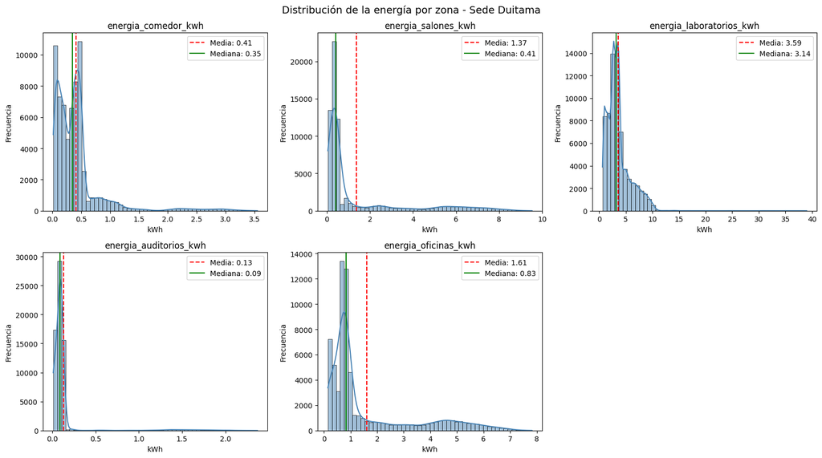

|  | asimetria |
| --- | --- |
| energia_comedor_kwh | 3.3856 |
| energia_salones_kwh | 1.9212 |
| energia_laboratorios_kwh | 2.1321 |
| energia_auditorios_kwh | 5.1985 |
| energia_oficinas_kwh | 1.5261 |

```python
# Histogramas de las variables energéticas
fig, axes = plt.subplots(2, 3, figsize=(16, 9))
axes = axes.flatten()

for ax, col in zip(axes, cols_energia):
    sns.histplot(df[col].dropna(), bins=50, kde=True, ax=ax, color='steelblue')
    ax.axvline(df[col].mean(), color='red', linestyle='--', label=f'Media: {df[col].mean():.2f}')
    ax.axvline(df[col].median(), color='green', linestyle='-', label=f'Mediana: {df[col].median():.2f}')
    ax.set_title(col)
    ax.set_xlabel('kWh')
    ax.set_ylabel('Frecuencia')
    ax.legend()

# Se oculta el eje sobrante (hay 5 variables y 6 espacios)
for ax in axes[len(cols_energia):]:
    ax.axis('off')

plt.suptitle('Distribución de la energía por zona - Sede Duitama', fontsize=14)
plt.tight_layout()
plt.show()

# Se mira el valor de asimetria para cada variable
desc['asimetria'] = df[cols_energia].skew()
display(desc['asimetria'].round(4))
```

**dtype:** float64

Los histogramas confirman visualmente lo que mostraban las estadísticas descriptivas.

- **Todas las distribuciones tienen asimetría positiva** (cola larga a la derecha): la mayoría de las lecturas se concentra en valores bajos y pocas lecturas alcanzan consumos altos. En todas, la línea de la media queda a la derecha de la mediana.
- Esa forma es coherente con el funcionamiento de un campus: consumos bajos de noche, fines de semana y festivos, y consumos altos en horas de clase y de laboratorio.
- En términos absolutos (kWh), **laboratorios y salones** muestran colas más largas y mayor dispersión, mientras que **auditorios y comedor** se concentran en valores muy bajos.

### 3.3. Imputación de valores nulos

```python
# Nulos antes de imputar
nulos_antes = df.isna().sum()
print(f'Valores nulos antes de imputar:')
nulos_antes = nulos_antes[nulos_antes > 0].sort_values(ascending=False)
display(nulos_antes)

reporte = []

# Variables numéricas: se imputan con la mediana (robusta frente a la asimetría y los atípicos)
cols_num = df.select_dtypes(include='number').columns
for col in cols_num:
    if df[col].isna().any():
        mediana = df[col].median()
        reporte.append({'variable': col, 'tipo': 'numérica', 'nulos imputados': int(df[col].isna().sum()), 'metodo': 'mediana', 'valor': round(mediana, 4)})
        df[col] = df[col].fillna(mediana)

# Variables categóricas: se imputan con la moda
cols_cat = df.select_dtypes(include=['object', 'string']).columns
for col in cols_cat:
    if df[col].isna().any():
        moda = df[col].mode()[0]
        reporte.append({'variable': col, 'tipo': 'categórica', 'nulos imputados': int(df[col].isna().sum()), 'metodo': 'moda', 'valor': moda})
        df[col] = df[col].fillna(moda)

# Resumen y validación
print('\nResumen de la imputación:')
display(pd.DataFrame(reporte))
print(f'Nulos restantes en df: {int(df.isna().sum().sum())}')
```

```
Valores nulos antes de imputar:
```

|  | 0 |
| --- | --- |
| ocupacion_pct | 8308 |
| temperatura_exterior_c | 4131 |
| co2_kg | 3369 |
| energia_auditorios_kwh | 3362 |
| agua_litros | 2754 |
| energia_comedor_kwh | 2079 |

**dtype:** int64

```
Resumen de la imputación:
```

|  | variable | tipo | nulos imputados | metodo | valor |
| --- | --- | --- | --- | --- | --- |
| 0 | energia_comedor_kwh | numérica | 2079 | mediana | 0.3511 |
| 1 | energia_auditorios_kwh | numérica | 3362 | mediana | 0.0883 |
| 2 | agua_litros | numérica | 2754 | mediana | 153.5200 |
| 3 | temperatura_exterior_c | numérica | 4131 | mediana | 15.0000 |
| 4 | ocupacion_pct | numérica | 8308 | mediana | 16.8000 |
| 5 | co2_kg | numérica | 3369 | mediana | 0.9705 |

```
Nulos restantes en df: 0
```

- **Mediana:** las distribuciones son muy asimétricas y con atípicos (en el dataset completo, agua: media 645 vs mediana 139; ocupación: 22,8 vs 15,9). La media inflaría los valores imputados.
- **Moda:** las variables de texto (`sede`, `sede_id`, `timestamp`, `dia_nombre`, `periodo_academico`) no tenían nulos, así que la imputación no cambia ningún valor.

Se imputaron las 6 variables con nulos usando la **mediana**: `ocupacion_pct` (8.308 nulos, mediana 16,8 %), `temperatura_exterior_c` (4.131; 15,0 °C), `co2_kg` (3.369; 0,97 kg), `energia_auditorios_kwh` (3.362; 0,088 kWh), `agua_litros` (2.754; 153,52 L) y `energia_comedor_kwh` (2.079; 0,351 kWh). La validación final muestra 0 nulos.

- La validación final debe mostrar **0 nulos restantes**, lo que deja el dataset listo para la matriz de correlación y el modelado.
- En `energia_comedor_kwh` y `energia_auditorios_kwh`, un nulo puede significar zona cerrada, y la mediana puede sobreestimar el consumo en esos casos.
- **Limitaciones:** la ocupación es la más afectada (8.308 nulos, 12,1 % de Duitama). Imputar con un único valor reduce la variabilidad y puede atenuar su relación con el consumo. Una mejora sería imputar por hora y tipo de día.
- En comedor y auditorios, un nulo puede ser zona cerrada, y la mediana podría sobreestimar el consumo.

### 3.4. Matriz de correlación

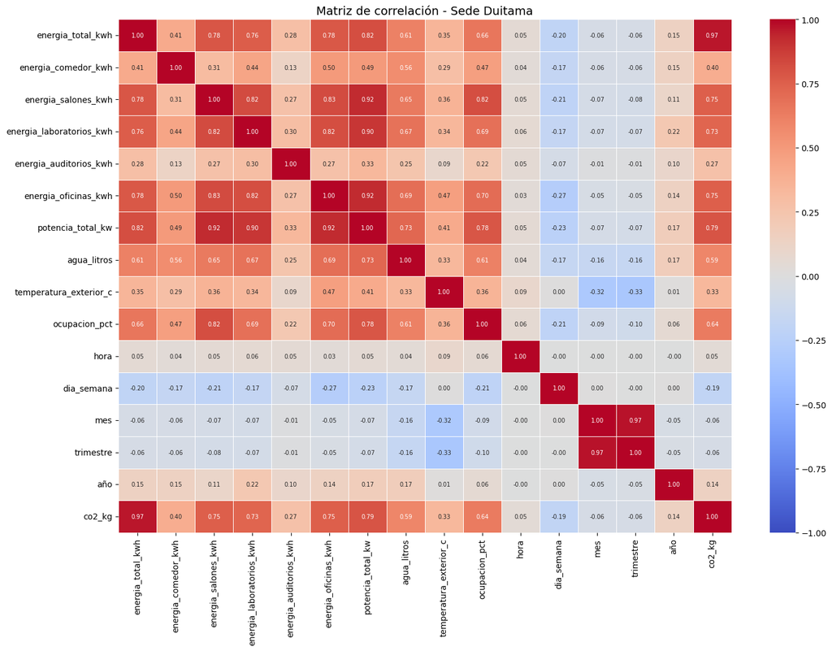

```python
# Variables numéricas (se excluye reading_id porque es solo un identificador)
cols_corr = [c for c in df.select_dtypes(include='number').columns if c != 'reading_id']
corr = df[cols_corr].corr()

plt.figure(figsize=(15, 11))
sns.heatmap(corr, annot=True, fmt='.2f', cmap='coolwarm', vmin=-1, vmax=1,
            linewidths=0.5, annot_kws={'size': 7})
plt.title('Matriz de correlación - Sede Duitama', fontsize=14)
plt.tight_layout()
plt.show()

# Correlación de cada variable con el consumo total de energía
print('Correlación con energia_total_kwh:')
corr['energia_total_kwh'].drop('energia_total_kwh').sort_values(ascending=False).round(3)
```

```
Correlación con energia_total_kwh:
```

|  | energia_total_kwh |
| --- | --- |
| co2_kg | 0.966 |
| potencia_total_kw | 0.820 |
| energia_salones_kwh | 0.781 |
| energia_oficinas_kwh | 0.781 |
| energia_laboratorios_kwh | 0.759 |
| ocupacion_pct | 0.662 |
| agua_litros | 0.610 |
| energia_comedor_kwh | 0.414 |
| temperatura_exterior_c | 0.346 |
| energia_auditorios_kwh | 0.284 |
| año | 0.147 |
| hora | 0.048 |
| mes | -0.058 |
| trimestre | -0.061 |
| dia_semana | -0.197 |

**dtype:** float64

La matriz de Pearson mide relaciones lineales. Con distribuciones asimétricas y atípicos puede subestimar relaciones reales, por lo que se interpreta con cautela. Correlaciones con `energia_total_kwh`:

- **Variables derivadas del consumo:** `co2_kg` (0,966) y `potencia_total_kw` (0,820) son casi redundantes con el total. Se calculan a partir de la energía o la miden en otra unidad, por lo que se excluyen del modelo (4.2).
- **Energía por zona:** salones y oficinas (0,781) y laboratorios (0,759) tienen correlación alta con el total. Comedor (0,414) y auditorios (0,284) son más débiles, coherente con su bajo peso (7,6 % del consumo).
- **Variables explicativas:** `ocupacion_pct` (0,662) es la más relevante de las que no derivan del consumo, seguida de `agua_litros` (0,610) y `temperatura_exterior_c` (0,346). Más ocupación implica más consumo.
- **Calendario:** `dia_semana` (−0,197) es negativa: el consumo baja hacia el fin de semana. `hora` (0,048), `mes` (−0,058) y `trimestre` (−0,061) tienen correlación lineal débil porque su efecto es cíclico y no lineal. `año` (0,147) sugiere un leve aumento del consumo con el tiempo.
- **Utilidad para el modelado:** conservar ocupación, temperatura y variables de calendario, descartar `co2_kg` y `potencia_total_kw` (fuga de información) y quedarse con `mes` en lugar de `trimestre`, porque este se deriva de aquel.

## 4. Preparación para modelado

### 4.1. Selección de variables objetivo y predictoras

```python
# --- Variables objetivo ---
objetivo_principal = 'energia_total_kwh'          # consumo total horario de la sede (kWh)
objetivos_sector = cols_energia                   # consumo por sector (comedor, salones, laboratorios, auditorios, oficinas)

# El timestamp debe ser fecha-hora para poder ordenar cronológicamente más adelante
df['timestamp'] = pd.to_datetime(df['timestamp'], errors='coerce')
print(f"Fechas no convertidas (NaT): {df['timestamp'].isna().sum()}")
df = df.dropna(subset=['timestamp'])
```

```
Fechas no convertidas (NaT): 0
```

En 2.3 se detectaron registros con `energia_total_kwh` negativo (155 en Duitama), pero la limpieza de 2.4 solo eliminó los 143 con CO₂ negativo. Por eso aquí se eliminan los negativos que quedaban, para que el objetivo sea físicamente válido.

se compara el total con la suma de las cinco zonas, ya que en el dataset completo el máximo del total (190,46 kWh) supera por mucho la suma de los máximos por zona (~63 kWh). La proporción de registros que no cuadran se imprime en la salida de la celda y se conserva para no perder datos, porque pueden ser picos reales.

```python
# Validación de la variable objetivo: en 2.3 hubo negativos en energia_total_kwh que la limpieza de 2.4 no cubría
neg_obj = (df[objetivo_principal] < 0).sum()
print(f'Registros con {objetivo_principal} negativo todavía presentes: {neg_obj}')
df = df[df[objetivo_principal] >= 0].reset_index(drop=True)
print(f'Registros disponibles para modelado: {len(df)}')

# Coherencia del objetivo: el total debería ser similar a la suma de las cinco zonas
suma_zonas = df[objetivos_sector].sum(axis=1)
dif_relativa = (df[objetivo_principal] - suma_zonas).abs() / suma_zonas
print(f'Registros donde el total difiere más de 20 % de la suma de zonas: {(dif_relativa > 0.2).mean() * 100:.2f} %')

display(df[objetivo_principal].describe().round(3))
```

```
Registros con energia_total_kwh negativo todavía presentes: 12
Registros disponibles para modelado: 68487
Registros donde el total difiere más de 20 % de la suma de zonas: 1.46 %
```

|  | energia_total_kwh |
| --- | --- |
| count | 68487.000 |
| mean | 7.261 |
| std | 7.334 |
| min | 0.000 |
| 25% | 3.572 |
| 50% | 5.005 |
| 75% | 9.311 |
| max | 190.455 |

**dtype:** float64

```python
# --- Variables predictoras (features) ---
features_origen = [
    'ocupacion_pct', 'temperatura_exterior_c',
    'hora', 'dia_semana', 'mes',
    'es_fin_semana', 'es_festivo', 'es_semana_parciales', 'es_semana_finales',
    'periodo_academico'
]
```

```python
justificacion = {
    'ocupacion_pct': 'Principal impulsor de la demanda (corr. 0,66 con el total)',
    'temperatura_exterior_c': 'Puede influir en climatización e iluminación (corr. 0,35)',
    'hora': 'Ciclo diario de actividad',
    'dia_semana': 'Diferencia días hábiles de fines de semana',
    'mes': 'Estacionalidad anual',
    'es_fin_semana': 'Menor actividad académica',
    'es_festivo': 'Menor actividad académica',
    'es_semana_parciales': 'Mayor uso de salones en evaluaciones',
    'es_semana_finales': 'Mayor uso de salones en evaluaciones',
    'periodo_academico': 'Semestre o vacaciones cambian el uso de la infraestructura'
}

roles = pd.DataFrame({
    'variable': [objetivo_principal] + objetivos_sector + features_origen,
    'rol': ['Objetivo principal'] + ['Objetivo por sector'] * len(objetivos_sector) + ['Predictora'] * len(features_origen),
    'justificación': ['Consumo total de la sede'] + ['Consumo del sector'] * len(objetivos_sector) + [justificacion[c] for c in features_origen]
})
roles
```

|  | variable | rol | justificación |
| --- | --- | --- | --- |
| 0 | energia_total_kwh | Objetivo principal | Consumo total de la sede |
| 1 | energia_comedor_kwh | Objetivo por sector | Consumo del sector |
| 2 | energia_salones_kwh | Objetivo por sector | Consumo del sector |
| 3 | energia_laboratorios_kwh | Objetivo por sector | Consumo del sector |
| 4 | energia_auditorios_kwh | Objetivo por sector | Consumo del sector |
| 5 | energia_oficinas_kwh | Objetivo por sector | Consumo del sector |
| 6 | ocupacion_pct | Predictora | Principal impulsor de la demanda (corr. 0,66 c... |
| 7 | temperatura_exterior_c | Predictora | Puede influir en climatización e iluminación (... |
| 8 | hora | Predictora | Ciclo diario de actividad |
| 9 | dia_semana | Predictora | Diferencia días hábiles de fines de semana |
| 10 | mes | Predictora | Estacionalidad anual |
| 11 | es_fin_semana | Predictora | Menor actividad académica |
| 12 | es_festivo | Predictora | Menor actividad académica |
| 13 | es_semana_parciales | Predictora | Mayor uso de salones en evaluaciones |
| 14 | es_semana_finales | Predictora | Mayor uso de salones en evaluaciones |
| 15 | periodo_academico | Predictora | Semestre o vacaciones cambian el uso de la inf... |

**Variable objetivo.** Se define como objetivo principal **`energia_total_kwh`**, el consumo horario de la sede, porque es una variable continua (problema de regresión) y responde directamente al propósito del taller: predecir el consumo y apoyar la optimización energética. Como objetivos secundarios se usan las **cinco energías por sector**, para entrenar modelos por zona e identificar dónde actuar (laboratorios concentra cerca del 50 % del consumo en Duitama).

**Variables predictoras.** Se eligen variables que se conocen antes de que ocurra el consumo y que el contexto del taller identifica como determinantes: ocupación, horarios académicos y calendario.

- `ocupacion_pct` tuvo la correlación más alta entre las predictoras elegidas (0,66) y `temperatura_exterior_c` una correlación moderada (0,35).
- `hora`, `dia_semana` y `mes` tienen correlación lineal baja con el total (0,05, −0,20 y −0,06), pero eso no significa que no influyan: son variables **cíclicas** y su efecto no es lineal. Por eso se transforman con seno y coseno en 4.3.
- Las banderas de calendario y `periodo_academico` capturan los cambios de actividad por festivos, evaluaciones y vacaciones.

### 4.2. Exclusión de variables no relevantes

```python
# Variables que NO se usan como predictoras y el motivo
excluidas = {
    'reading_id': 'Identificador de la lectura; no tiene valor predictivo',
    'timestamp': 'Solo se usa para ordenar y dividir cronológicamente; sus componentes ya están en hora, día y mes',
    'sede': 'Constante: solo contiene Duitama después del filtrado',
    'sede_id': 'Constante: solo contiene Duitama después del filtrado',
    'dia_nombre': 'Redundante con dia_semana',
    'trimestre': 'Redundante con mes (se deriva de él)',
    'año': 'Tomaría valores fuera del rango de entrenamiento al predecir años futuros; se usa solo para la validación temporal',
    'potencia_total_kw': 'Mide el mismo fenómeno que la energía (corr. 0,82 con el total): fuga de información',
    'co2_kg': 'Se calcula a partir de la energía (corr. 0,97 con el total): fuga de información',
    'agua_litros': 'Se mide al mismo tiempo que el consumo y no se conoce de antemano; además tiene atípicos extremos (hasta 62.606 L)'
}

tabla_exclusion = pd.DataFrame({'variable': list(excluidas.keys()), 'motivo de exclusión': list(excluidas.values())})
display(tabla_exclusion)

# Las energías por zona son componentes del total (objetivo), por lo que tampoco son predictoras
print('Energías por zona: se usan como objetivos secundarios, no como predictoras:')
print(objetivos_sector)

# Verificación: todas las columnas deben estar clasificadas
clasificadas = [objetivo_principal] + objetivos_sector + features_origen + list(excluidas.keys())
sin_clasificar = [c for c in df.columns if c not in clasificadas]
print(f'\nColumnas sin clasificar: {sin_clasificar}')
print(f'Resumen: {len(features_origen)} predictoras, {1 + len(objetivos_sector)} objetivos, {len(excluidas)} excluidas, de {df.shape[1]} columnas')
```

|  | variable | motivo de exclusión |
| --- | --- | --- |
| 0 | reading_id | Identificador de la lectura; no tiene valor pr... |
| 1 | timestamp | Solo se usa para ordenar y dividir cronológica... |
| 2 | sede | Constante: solo contiene Duitama después del f... |
| 3 | sede_id | Constante: solo contiene Duitama después del f... |
| 4 | dia_nombre | Redundante con dia_semana |
| 5 | trimestre | Redundante con mes (se deriva de él) |
| 6 | año | Tomaría valores fuera del rango de entrenamien... |
| 7 | potencia_total_kw | Mide el mismo fenómeno que la energía (corr. 0... |
| 8 | co2_kg | Se calcula a partir de la energía (corr. 0,97 ... |
| 9 | agua_litros | Se mide al mismo tiempo que el consumo y no se... |

```
Energías por zona: se usan como objetivos secundarios, no como predictoras:
['energia_comedor_kwh', 'energia_salones_kwh', 'energia_laboratorios_kwh', 'energia_auditorios_kwh', 'energia_oficinas_kwh']

Columnas sin clasificar: []
Resumen: 10 predictoras, 6 objetivos, 10 excluidas, de 26 columnas
```

Se excluyen **10 variables** por cuatro tipos de motivo:

- **Sin valor predictivo o constantes:** `reading_id` (identificador), `sede` y `sede_id` (solo existe Duitama después del filtrado) y `timestamp` (se conserva únicamente para ordenar y dividir los datos, ya que su información está en `hora`, `dia_semana` y `mes`).
- **Redundantes:** `dia_nombre` repite a `dia_semana` y `trimestre` se deriva de `mes`. Mantener ambas versiones solo agrega colinealidad.
- **Fuga de información (data leakage):** `potencia_total_kw` (corr. 0,82) y `co2_kg` (corr. 0,97) son consecuencia directa del consumo de energía. Aportarían una correlación alta, pero el modelo no podría usarlas para predecir y daría métricas engañosas. Por la misma razón, las energías por zona no son predictoras del total.
- **No disponibles antes de predecir o poco confiables:** `agua_litros` se registra al mismo tiempo que el consumo y tiene valores extremos, aunque su correlación con el total es moderada (0,61). `año` se excluye porque en producción tomaría valores fuera del rango de entrenamiento y se usa solo para la validación temporal.

La verificación final confirma que **todas las columnas quedaron clasificadas** como objetivo, predictora o excluida, sin variables sin justificar.

### 4.3. Conjunto final para entrenamiento

```python
# Libreria para estandarizar el escalado
from sklearn.preprocessing import StandardScaler
```

```python
# 1) Codificación cíclica de hora, día de la semana y mes (la hora 23 está al lado de la hora 0)
df['hora_sin'] = np.sin(2 * np.pi * df['hora'] / 24)
df['hora_cos'] = np.cos(2 * np.pi * df['hora'] / 24)
df['dia_sin'] = np.sin(2 * np.pi * df['dia_semana'] / 7)
df['dia_cos'] = np.cos(2 * np.pi * df['dia_semana'] / 7)
df['mes_sin'] = np.sin(2 * np.pi * df['mes'] / 12)
df['mes_cos'] = np.cos(2 * np.pi * df['mes'] / 12)

# 2) Banderas booleanas a enteros (0/1)
banderas = ['es_fin_semana', 'es_festivo', 'es_semana_parciales', 'es_semana_finales']
df[banderas] = df[banderas].astype(int)

# 3) Variable categórica a variables dummy (se elimina una categoría para evitar colinealidad)
dummies = pd.get_dummies(df['periodo_academico'], prefix='periodo', drop_first=True, dtype=int)

# 4) Conjunto final: marca de tiempo + predictoras + objetivos
cols_X = (['ocupacion_pct', 'temperatura_exterior_c',
           'hora_sin', 'hora_cos', 'dia_sin', 'dia_cos', 'mes_sin', 'mes_cos']
          + banderas + list(dummies.columns))

df_modelo = pd.concat([df[['timestamp']], df[['ocupacion_pct', 'temperatura_exterior_c',
                                              'hora_sin', 'hora_cos', 'dia_sin', 'dia_cos',
                                              'mes_sin', 'mes_cos'] + banderas],
                       dummies, df[[objetivo_principal] + objetivos_sector]], axis=1)
df_modelo = df_modelo.sort_values('timestamp').reset_index(drop=True)

print(f'Conjunto final: {df_modelo.shape[0]} filas x {df_modelo.shape[1]} columnas')
print(f'Predictoras: {len(cols_X)} | Nulos en el conjunto final: {int(df_modelo.isna().sum().sum())}')

# 5) División cronológica 80 % entrenamiento / 20 % prueba (sin mezclar el orden temporal)
corte = int(len(df_modelo) * 0.8)
train = df_modelo.iloc[:corte]
test = df_modelo.iloc[corte:]

X_train, X_test = train[cols_X], test[cols_X]
y_train, y_test = train[objetivo_principal], test[objetivo_principal]
y_train_sector, y_test_sector = train[objetivos_sector], test[objetivos_sector]

print(f"\nEntrenamiento: {X_train.shape[0]} filas ({train['timestamp'].min().date()} a {train['timestamp'].max().date()})")
print(f"Prueba:        {X_test.shape[0]} filas ({test['timestamp'].min().date()} a {test['timestamp'].max().date()})")

# 6) Escalado de las variables continuas (el escalador se ajusta solo con el entrenamiento)
cols_escalar = ['ocupacion_pct', 'temperatura_exterior_c']
escalador = StandardScaler().fit(X_train[cols_escalar])

X_train_esc = X_train.copy()
X_test_esc = X_test.copy()
X_train_esc[cols_escalar] = escalador.transform(X_train[cols_escalar])
X_test_esc[cols_escalar] = escalador.transform(X_test[cols_escalar])

display(X_train_esc.head())
display(X_train.dtypes.value_counts())
```

```
Conjunto final: 68487 filas x 26 columnas
Predictoras: 19 | Nulos en el conjunto final: 0

Entrenamiento: 54789 filas (2018-01-01 a 2024-04-06)
Prueba:        13698 filas (2024-04-07 a 2025-10-31)
```

|  | ocupacion_pct | temperatura_exterior_c | hora_sin | hora_cos | dia_sin | dia_cos | mes_sin | mes_cos | es_fin_semana | es_festivo | es_semana_parciales | es_semana_finales | periodo_Semestre_1 | periodo_semestre1 | periodo_semestre_1 | periodo_semestre_2 | periodo_vacaciones | periodo_vacaciones_fin | periodo_vacaciones_mitad |
| --- | --- | --- | --- | --- | --- | --- | --- | --- | --- | --- | --- | --- | --- | --- | --- | --- | --- | --- | --- |
| 0 | -0.926032 | -0.875622 | 0.000000 | 1.000000 | 0.0 | 1.0 | 0.5 | 0.866025 | 0 | 1 | 0 | 0 | 0 | 0 | 0 | 0 | 0 | 1 | 0 |
| 1 | -0.905407 | -1.086790 | 0.258819 | 0.965926 | 0.0 | 1.0 | 0.5 | 0.866025 | 0 | 1 | 0 | 0 | 0 | 0 | 0 | 0 | 0 | 1 | 0 |
| 2 | -0.926032 | -1.488009 | 0.500000 | 0.866025 | 0.0 | 1.0 | 0.5 | 0.866025 | 0 | 1 | 0 | 0 | 0 | 0 | 0 | 0 | 0 | 1 | 0 |
| 3 | -0.848687 | -1.107907 | 0.707107 | 0.707107 | 0.0 | 1.0 | 0.5 | 0.866025 | 0 | 1 | 0 | 0 | 0 | 0 | 0 | 0 | 0 | 1 | 0 |
| 4 | -0.895094 | -0.960090 | 0.866025 | 0.500000 | 0.0 | 1.0 | 0.5 | 0.866025 | 0 | 1 | 0 | 0 | 0 | 0 | 0 | 0 | 0 | 1 | 0 |

|  | count |
| --- | --- |
| int64 | 11 |
| float64 | 8 |

**dtype:** int64

**Análisis:**